# Random Forest

# Tarea 5.

# Metodos supervisados

Librerias

```r
library(caTools)
library(rpart)
library(randomForest)
library(tidyverse)
library(GGally)
```

1. Desarolle el Análisis del Problema

```r
# Construya el análisis del problema


# Este conjunto de datos incluye descripciones de muestras hipotéticas correspondientes a 23 especies de # hongos branquiales en el hongo de la familia Agaricus y Lepiota extraídas de la Guía de campo de la # # Sociedad Audubon de hongos de América del Norte (1981). Cada especie se identifica como definitivamente # comestible, definitivamente venenosa o de comestibilidad desconocida y no se recomienda. Esta última # # clase se combinó con la venenosa. La Guía establece claramente que no existe una regla simple para # # # determinar la comestibilidad de un hongo; ninguna regla como "folletos tres, que así sea" para el # roble venenoso y la hiedra.
```

Fuente del dataset: https://archive.ics.uci.edu/ml/machine-learning-databases/mushroom/agaricus-lepiota.data

1. Cargue el archivo agaricus_lepiota.data.csv en una variable

```r
agaricus <- read.csv("agaricus-lepiota.data", header = F, na.strings = "?")
names(agaricus) <- c("class",
                     "cap_shape",
                     "cap_surface",
                     "cap_color",
                     "bruises",
                     "odor",
                     "gill_attachment",
                     "gill_spacing",
                     "gill_size",
                     "gill_color",
                     "stalk_shape",
                     "stalk_root",
                     "stalk_surface_above_ring",
                     "stalk_surface_below_ring",
                     "stalk_color_above_ring",
                     "stalk_color_below_ring",
                     "veil_type",
                     "veil_color",
                     "ring_number",
                     "ring_type",
                     "spore_print_color",
                     "population",
                     "habitat")


agaricus$class <- factor(agaricus$class,
                         levels = c("e", "p"),
                         labels = c("edible","poisonous"))

agaricus$cap_shape <- factor(agaricus$cap_shape,
                            levels = c("b", "c", "f", "k", "s", "x"),
                            labels = c("bell","conical","flat", "knobbed", "sunken", "convex"))

agaricus$cap_surface <- factor(agaricus$cap_surface,
                               levels = c("f", "g", "s", "y"),
                               labels = c("fibrous","grooves","smooth","scaly"))

agaricus$cap_color <- factor(agaricus$cap_color,
                             levels = c("b", "c", "e", "g", "n", "p", "r", "u", "w", "y"),
                             labels = c("buff", "cinnamon", "red", "gray", "brown", "pink", "green",
                                        "purple", "white", "yellow"))

agaricus$bruises <- factor(agaricus$bruises,
                           levels = c("f", "t"),
                           labels = c("false", "true"))

agaricus$odor <- factor(agaricus$odor,
                             levels = c("a", "c", "f", "l", "m", "n", "p", "s", "y"),
                             labels = c("almond", "creosote", "foul", "anise", "musty", "none", "pungent",
                                        "spicy", "fishy"))

agaricus$gill_attachment <- factor(agaricus$gill_attachment,
                               levels = c("a", "f"),
                               labels = c("attached", "free"))

agaricus$gill_spacing <- factor(agaricus$gill_spacing,
                               levels = c("c", "w"),
                               labels = c("close", "crowded"))

agaricus$gill_size <- factor(agaricus$gill_size,
                               levels = c("b", "n"),
                               labels = c("broad", "narrow"))

agaricus$gill_color <- factor(agaricus$gill_color,
                             levels = c("b", "e", "g", "h", "k", "n", "o", "p", "r", "u", "w", "y"),
                             labels = c("buff", "red", "gray", "chocolate", "black", "brown", "orange", "pink",
                                        "green","purple", "white", "yellow"))

agaricus$stalk_shape <- factor(agaricus$stalk_shape,
                               levels = c("e", "t"),
                               labels = c("enlarging", "tapering"))

agaricus$stalk_root <- factor(agaricus$stalk_root,
                               levels = c("b", "c", "e", "r"),
                               labels = c("bulbous", "club", "equal", "rooted"))

agaricus$stalk_surface_above_ring <- factor(agaricus$stalk_surface_above_ring,
                               levels = c("f", "k", "s", "y"),
                               labels = c("fibrous", "silky", "smooth", "scaly"))

agaricus$stalk_surface_below_ring <- factor(agaricus$stalk_surface_below_ring,
                               levels = c("f", "k", "s", "y"),
                               labels = c("fibrous", "silky", "smooth", "scaly"))

agaricus$stalk_color_above_ring <- factor(agaricus$stalk_color_above_ring,
                               levels = c("b", "c", "e", "g", "n", "o", "p", "w", "y"),
                               labels = c("buff", "cinnamon", "red", "gray", "brown", "orange", "pink",
                                          "white", "yellow"))

agaricus$stalk_color_below_ring <- factor(agaricus$stalk_color_below_ring,
                               levels = c("b", "c", "e", "g", "n", "o", "p", "w", "y"),
                               labels = c("buff", "cinnamon", "red", "gray", "brown", "orange", "pink",
                                          "white", "yellow"))

agaricus$veil_type <- factor(agaricus$veil_type,
                               levels = c("p", "u"),
                               labels = c("partial", "universal"))

agaricus$veil_color <- factor(agaricus$veil_color,
                               levels = c("n", "o", "w", "y"),
                               labels = c("brown", "orange", "white", "yellow"))

agaricus$ring_number <- factor(agaricus$ring_number,
                               levels = c("n", "o", "t"),
                               labels = c("none", "one", "two"))

agaricus$ring_type <- factor(agaricus$ring_type,
                               levels = c("e", "f", "l", "n", "p"),
                               labels = c("evanescent", "flaring", "large", "none", "pendant"))

agaricus$spore_print_color <- factor(agaricus$spore_print_color,
                               levels = c("b", "h", "k", "n", "o", "r", "u", "w", "y"),
                               labels = c("buff", "chocolate", "black", "brown", "orange","green",
                                          "purple", "white", "yellow"))

agaricus$population <- factor(agaricus$population,
                               levels = c("a", "c", "n", "s", "v", "y"),
                               labels = c("abundant", "clustered", "numerous", "scattered", "several", "solitary"))

agaricus$habitat <- factor(agaricus$habitat,
                               levels = c("d", "g", "l", "m", "p", "u", "w"),
                               labels = c("woods", "grasses", "leaves", "meadows", "paths", "urban", "waste"))
```

## revisando el numero de NA en la columna stalk_root, este coincide con el del enunciado (2480)

```r
sum(is.na(agaricus$stalk_root))
```

```
## [1] 2480
```

## y en todo el dataframe el numero es el mismo, por lo que no hay mas NAs

```r
sum(is.na(agaricus))
```

```
## [1] 2480
```

2. Desarolle el Entendimiento de los Datos

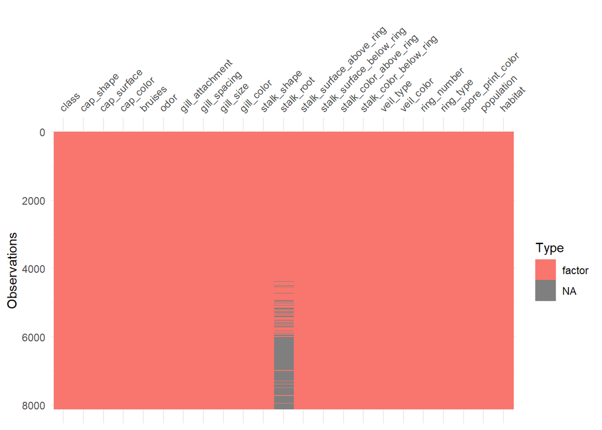

```r
visdat::vis_dat(agaricus)
```

```r
levels(agaricus$stalk_root)
```

```
## [1] "bulbous" "club"    "equal"   "rooted"
```

3. Utilizando barplot cree un gráfico de los atributos del dataset, observe las correlaciones entre atributos

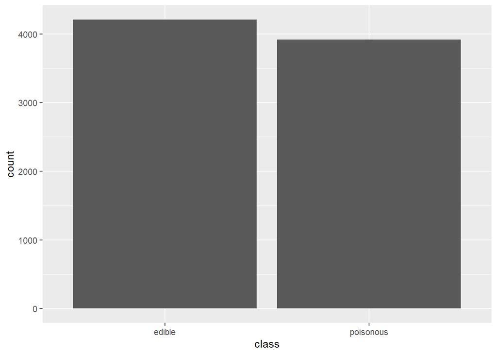

```r
bp_1 <- ggplot(data=agaricus) + geom_bar(aes(x=class))
bp_2 <- ggplot(data=agaricus) + geom_bar(aes(x=cap_shape))
bp_3 <- ggplot(data=agaricus) + geom_bar(aes(x=cap_surface))
bp_4 <- ggplot(data=agaricus) + geom_bar(aes(x=cap_color))
bp_5 <- ggplot(data=agaricus) + geom_bar(aes(x=bruises))
bp_6 <- ggplot(data=agaricus) + geom_bar(aes(x=odor))
bp_7 <- ggplot(data=agaricus) + geom_bar(aes(x=gill_attachment))
bp_8 <- ggplot(data=agaricus) + geom_bar(aes(x=gill_spacing))
bp_9 <- ggplot(data=agaricus) + geom_bar(aes(x=gill_size))
bp_10 <- ggplot(data=agaricus) + geom_bar(aes(x=gill_color))
bp_11 <- ggplot(data=agaricus) + geom_bar(aes(x=stalk_shape))
bp_12 <- ggplot(data=agaricus) + geom_bar(aes(x=stalk_root))
bp_13 <- ggplot(data=agaricus) + geom_bar(aes(x=stalk_surface_above_ring))
bp_14 <- ggplot(data=agaricus) + geom_bar(aes(x=stalk_surface_below_ring))
bp_15 <- ggplot(data=agaricus) + geom_bar(aes(x=stalk_color_above_ring))
bp_16 <- ggplot(data=agaricus) + geom_bar(aes(x=stalk_color_below_ring))
bp_17 <- ggplot(data=agaricus) + geom_bar(aes(x=veil_type))
bp_18 <- ggplot(data=agaricus) + geom_bar(aes(x=veil_color))
bp_19 <- ggplot(data=agaricus) + geom_bar(aes(x=ring_number))
bp_20 <- ggplot(data=agaricus) + geom_bar(aes(x=ring_type))
bp_21 <- ggplot(data=agaricus) + geom_bar(aes(x=spore_print_color))
bp_22 <- ggplot(data=agaricus) + geom_bar(aes(x=population))
bp_23 <- ggplot(data=agaricus) + geom_bar(aes(x=habitat))

bp_1
```

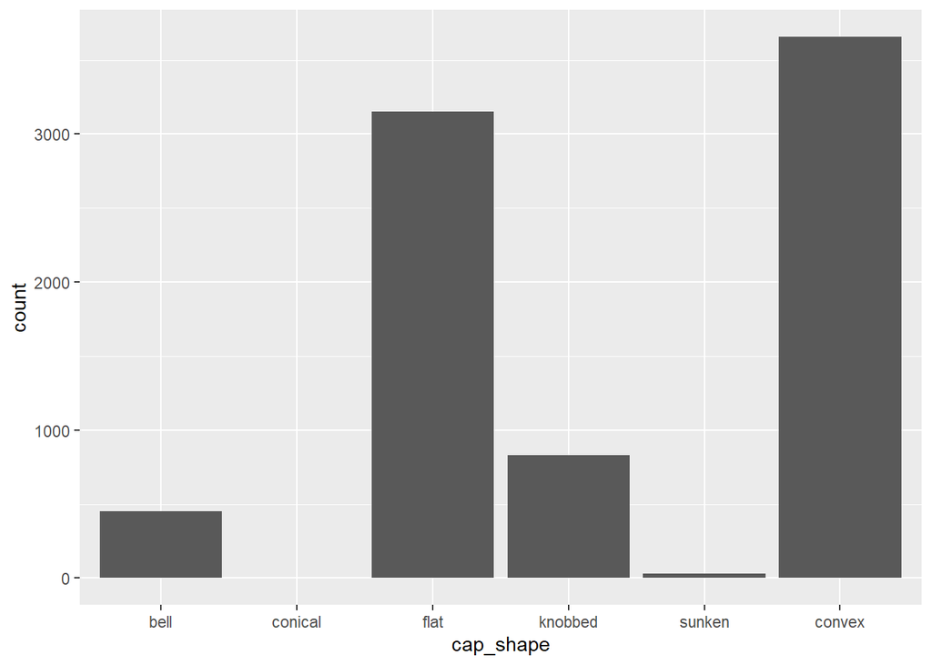

```r
bp_2
```

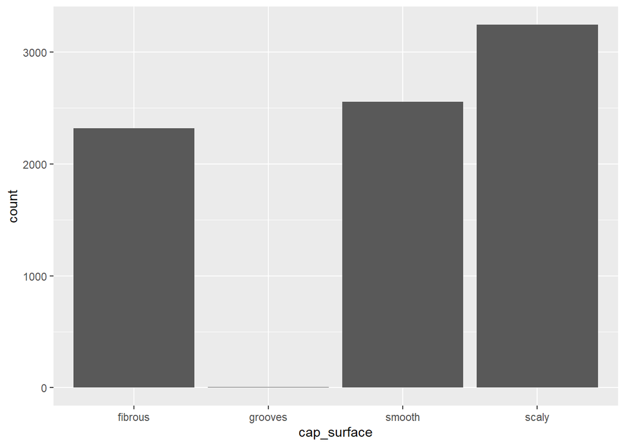

```r
bp_3
```

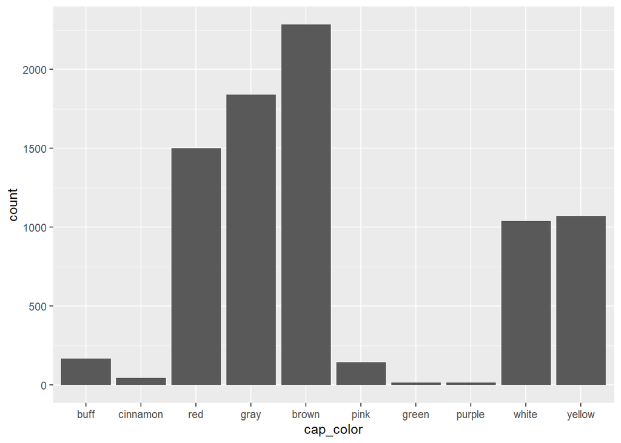

```r
bp_4
```

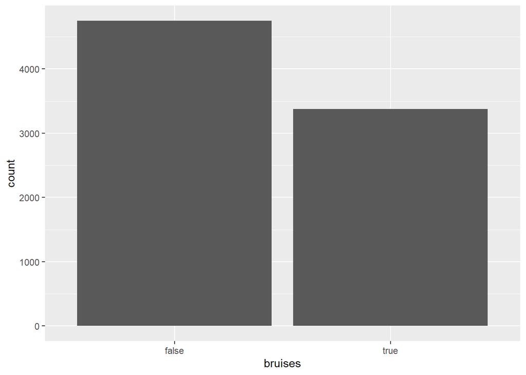

```r
bp_5
```

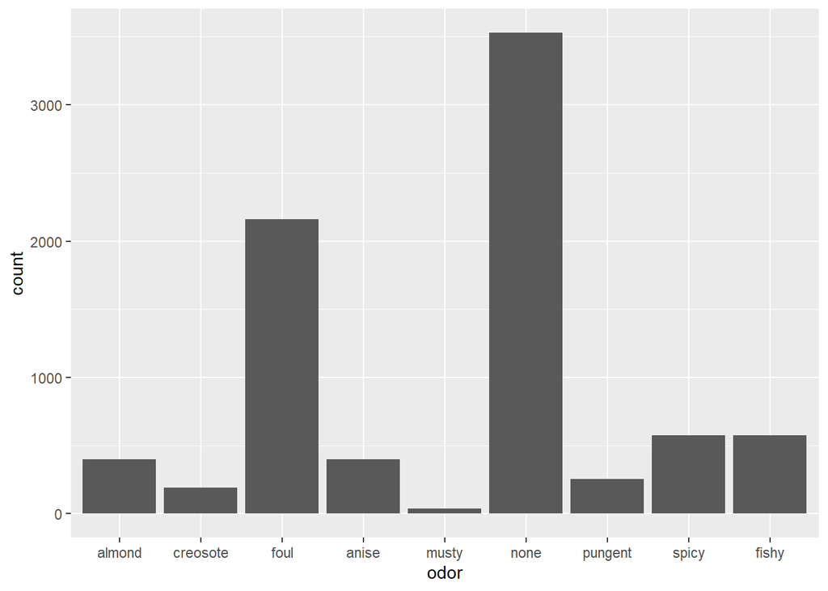

```r
bp_6
```

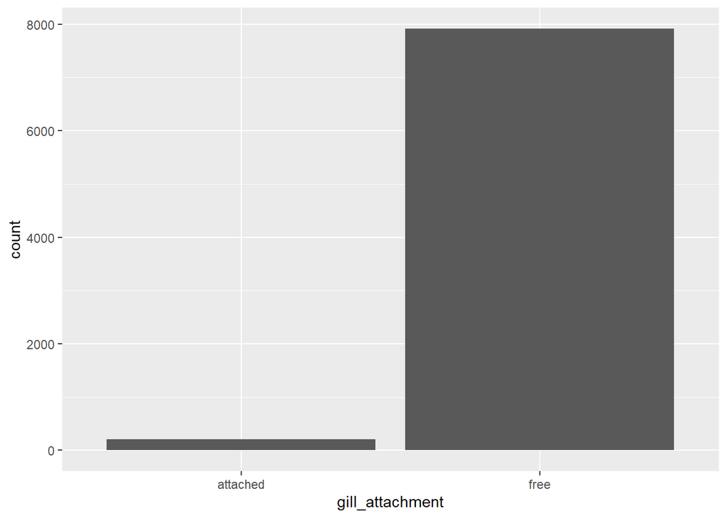

```r
bp_7
```

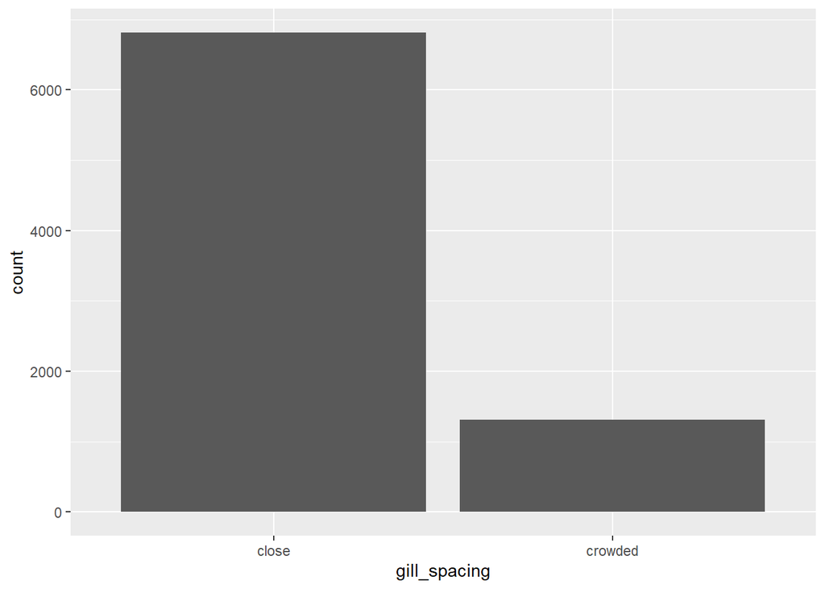

```r
bp_8
```

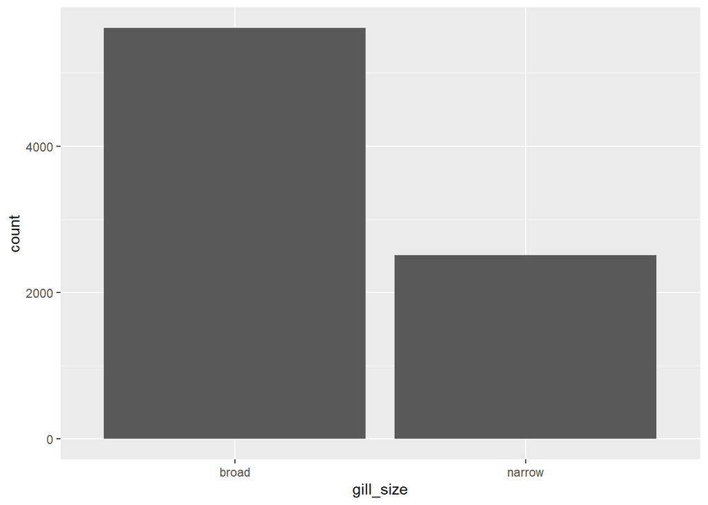

```r
bp_9
```

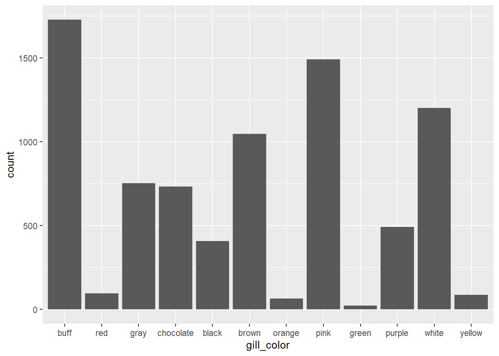

```r
bp_10
```

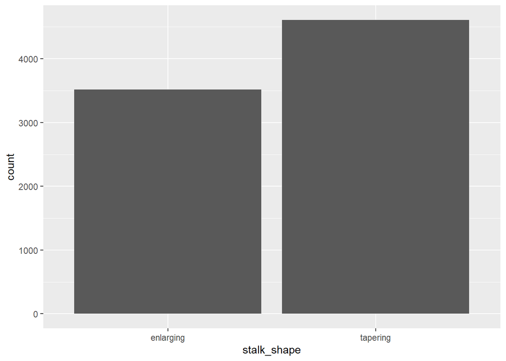

```r
bp_11
```

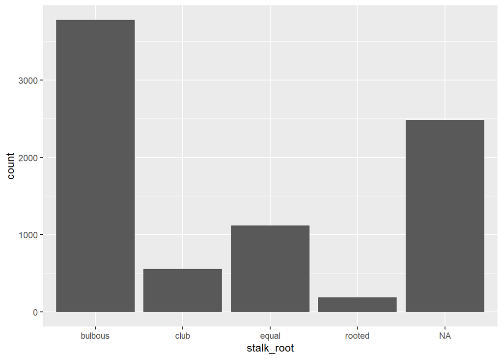

```r
bp_12
```

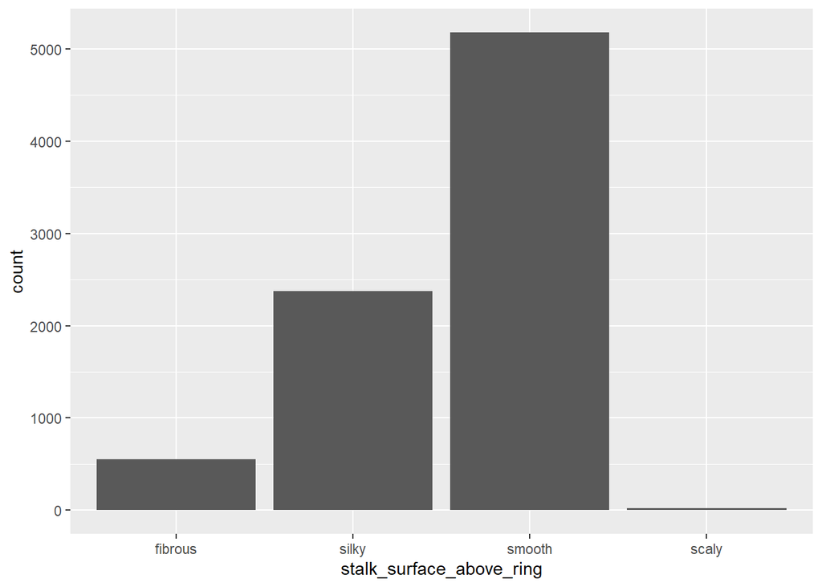

```r
bp_13
```

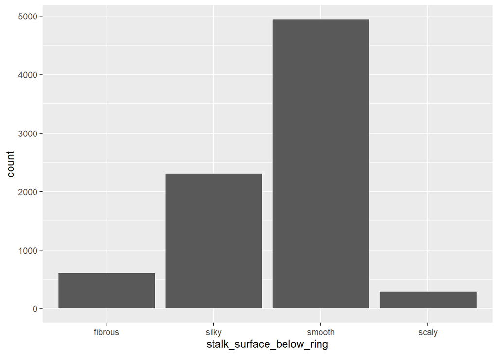

```r
bp_14
```

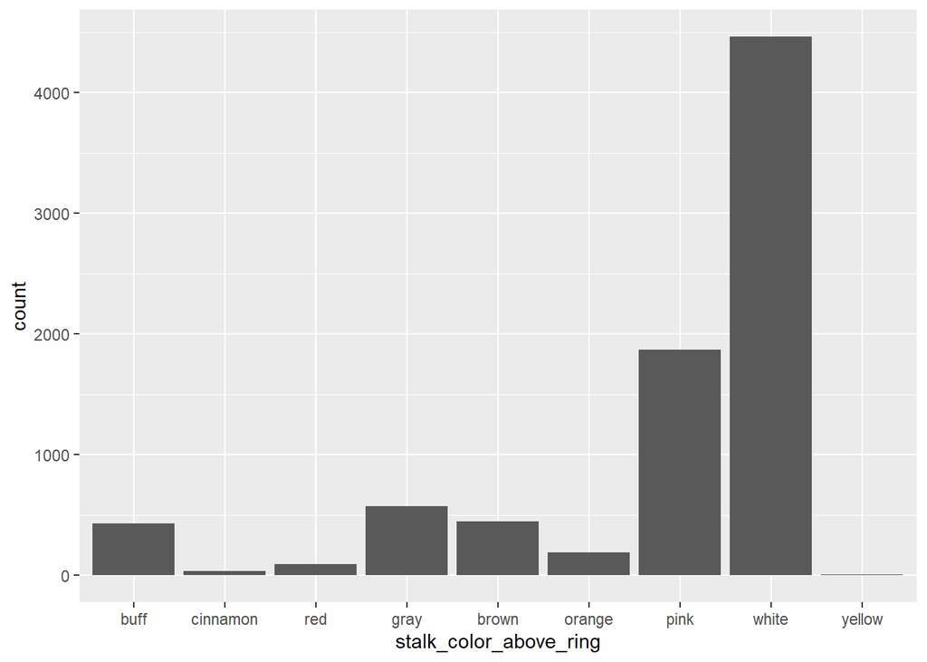

```r
bp_15
```

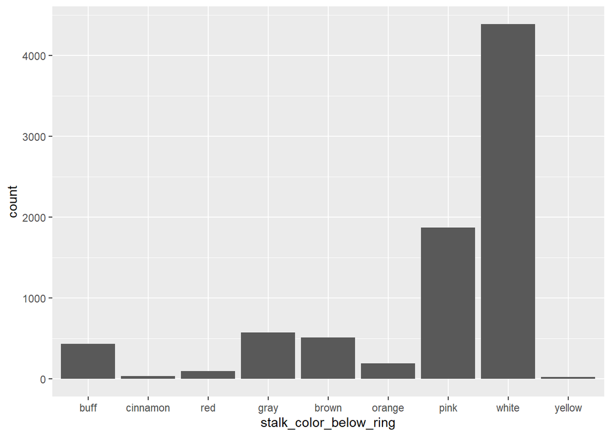

```r
bp_16
```

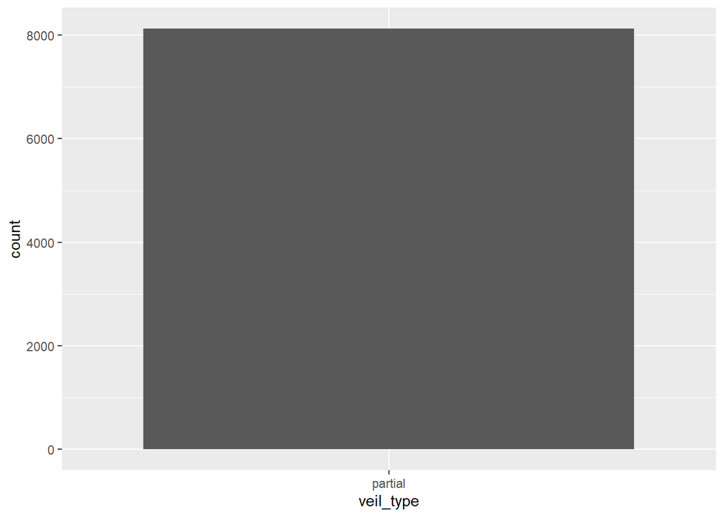

```r
bp_17
```

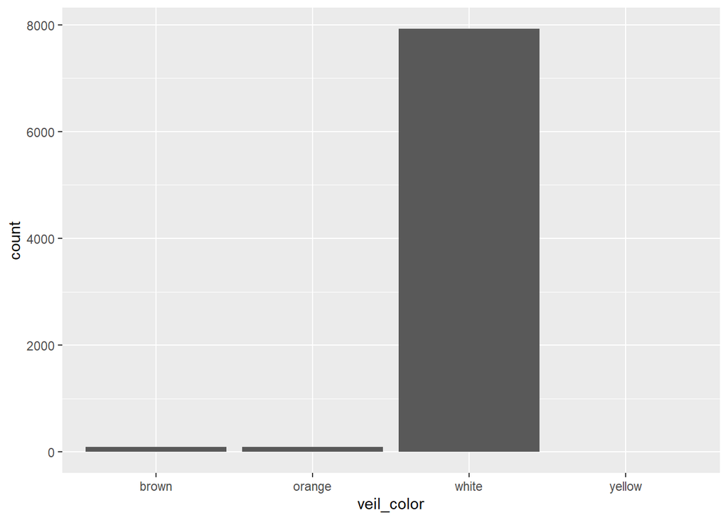

```r
bp_18
```

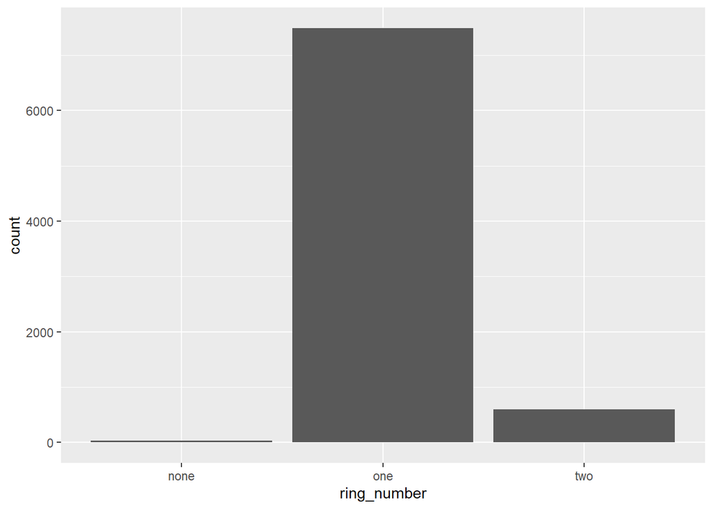

```r
bp_19
```

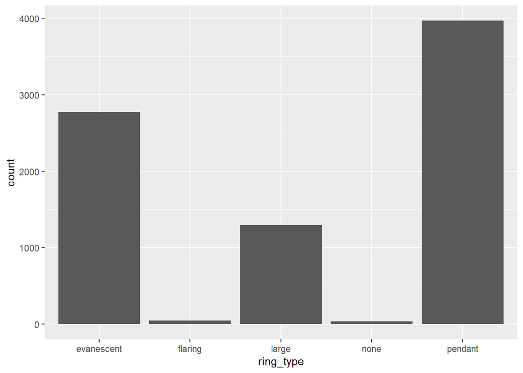

```r
bp_20
```

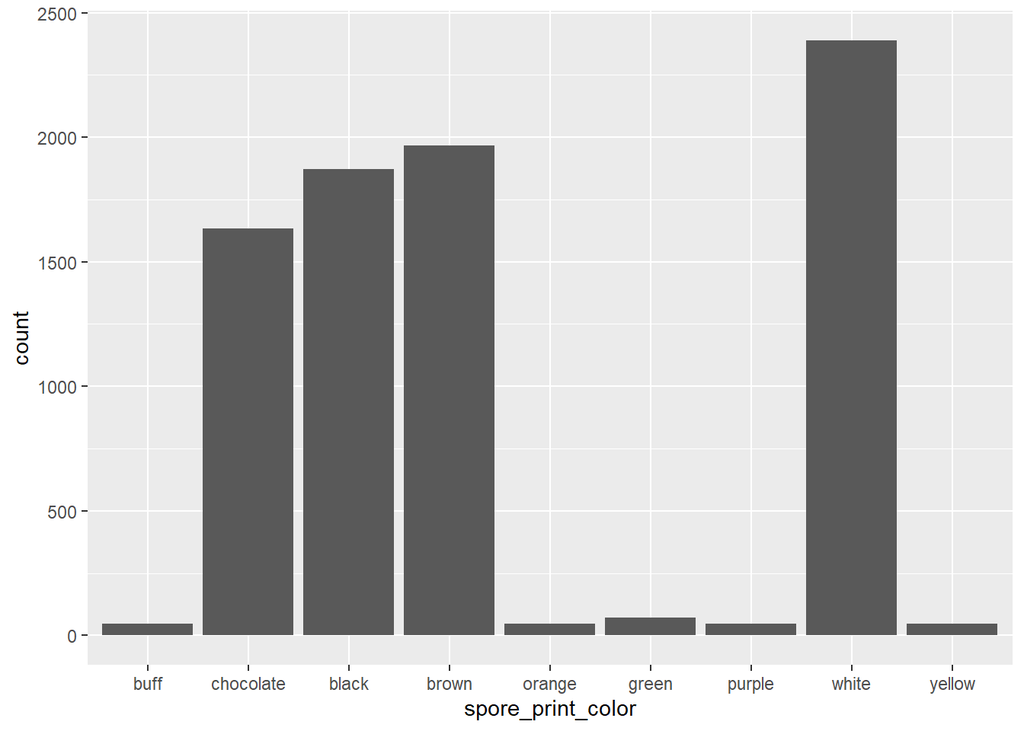

```r
bp_21
```

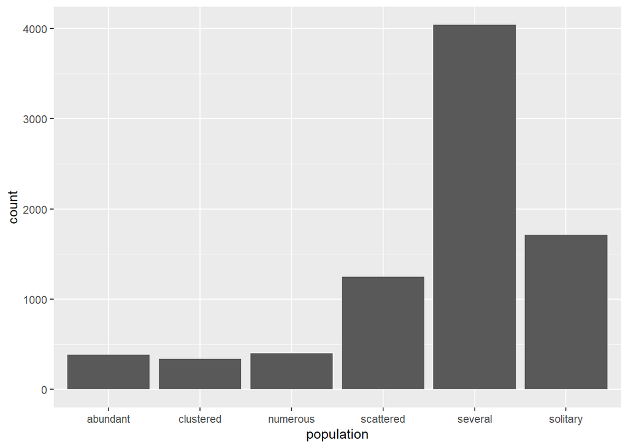

```r
bp_22
```

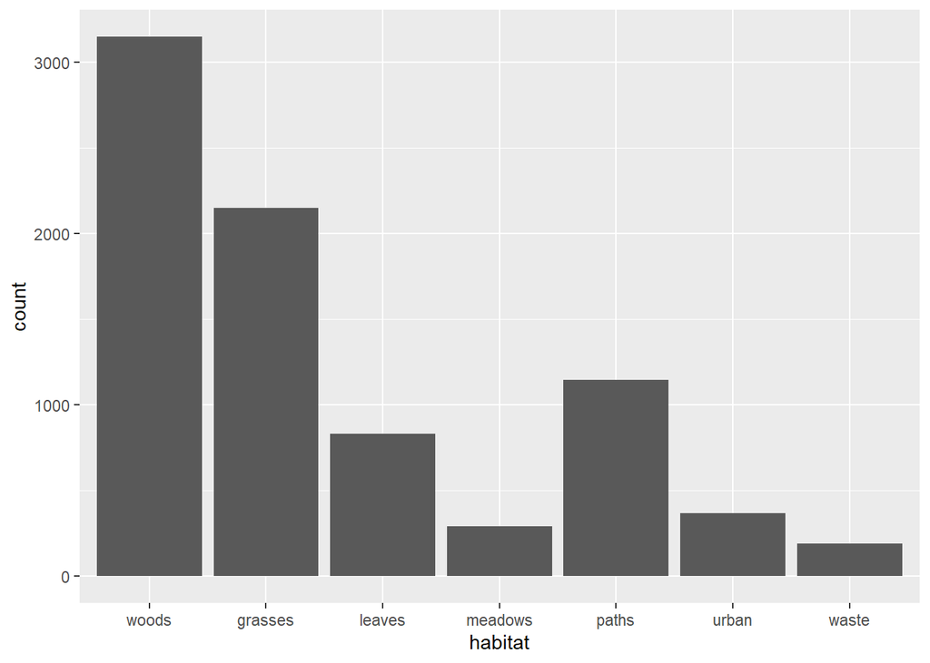

```r
bp_23
```

de la informacion que se puede observar en los graficos anteriores, un detalle interesante es que en la variable “veil_type” (boxplot 17), todas las observaciones son “partial”, o sea esta variable no aporta informacion util para un modelo pues un valor constante.

```r
levels(agaricus$veil_type)
```

```
## [1] "partial"   "universal"
```

```r
length(agaricus$veil_type != "partial")
```

```
## [1] 8124
```

```r
sum(agaricus$veil_type != "partial")
```

```
## [1] 0
```

```r
sum(agaricus$veil_type == "partial")
```

```
## [1] 8124
```

ademas en el vis_dat se puede observar que existen una cantidad importante de NAs en la variable “stalk_root” (poco mas de un 30% de los datos de la variable)

```r
100 * sum(is.na(agaricus$stalk_root)) / length(agaricus$stalk_root)
```

```
## [1] 30.52683
```

dado los puntos anteriores, se elimina la variable “veil_type” y “stalk root” (pues random forest no permite NA)

```r
agaricus <- agaricus %>% select(c(-veil_type))
agaricus <- agaricus %>% select(c(-stalk_root))
glimpse(agaricus)
```

```
## Observations: 8,124
## Variables: 21
## $ class                    <fct> poisonous, edible, edible, poisonous,...
## $ cap_shape                <fct> convex, convex, bell, convex, convex,...
## $ cap_surface              <fct> smooth, smooth, smooth, scaly, smooth...
## $ cap_color                <fct> brown, yellow, white, white, gray, ye...
## $ bruises                  <fct> true, true, true, true, false, true, ...
## $ odor                     <fct> pungent, almond, anise, pungent, none...
## $ gill_attachment          <fct> free, free, free, free, free, free, f...
## $ gill_spacing             <fct> close, close, close, close, crowded, ...
## $ gill_size                <fct> narrow, broad, broad, narrow, broad, ...
## $ gill_color               <fct> black, black, brown, brown, black, br...
## $ stalk_shape              <fct> enlarging, enlarging, enlarging, enla...
## $ stalk_surface_above_ring <fct> smooth, smooth, smooth, smooth, smoot...
## $ stalk_surface_below_ring <fct> smooth, smooth, smooth, smooth, smoot...
## $ stalk_color_above_ring   <fct> white, white, white, white, white, wh...
## $ stalk_color_below_ring   <fct> white, white, white, white, white, wh...
## $ veil_color               <fct> white, white, white, white, white, wh...
## $ ring_number              <fct> one, one, one, one, one, one, one, on...
## $ ring_type                <fct> pendant, pendant, pendant, pendant, e...
## $ spore_print_color        <fct> black, brown, brown, black, brown, bl...
## $ population               <fct> scattered, numerous, numerous, scatte...
## $ habitat                  <fct> urban, grasses, meadows, urban, grass...
```

se realiza la distribucion del conjunto de datos en datos de prueba y de entrenamiento.

```r
set.seed(123456789)
split_var <- sample.split(agaricus$class, SplitRatio = 0.7)
agaricus_training <- agaricus[split_var,]
agaricus_test <- agaricus[!split_var,]
```

se prueban que los tamanos sean acorde a los valores dados, donde se comprueba que el 70% de los datos esta en el set de entrenamiento y 30% en el de pruebas

```r
100 * length(agaricus_training$class) / length(agaricus$class)
```

```
## [1] 70.00246
```

```r
100 * length(agaricus_test$class) / length(agaricus$class)
```

```
## [1] 29.99754
```

y se puede comprobar que ademas la disribucion fue muy pareja en cuanto a la variable class para ambos set de datos

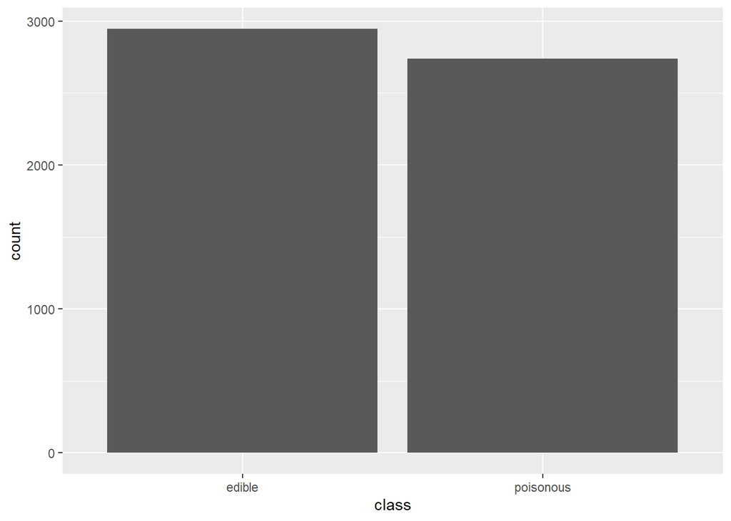

```r
bp_tr1 <- ggplot(data=agaricus_training) + geom_bar(aes(x=class))
bp_te1 <- ggplot(data=agaricus_test) + geom_bar(aes(x=class))

bp_tr1
```

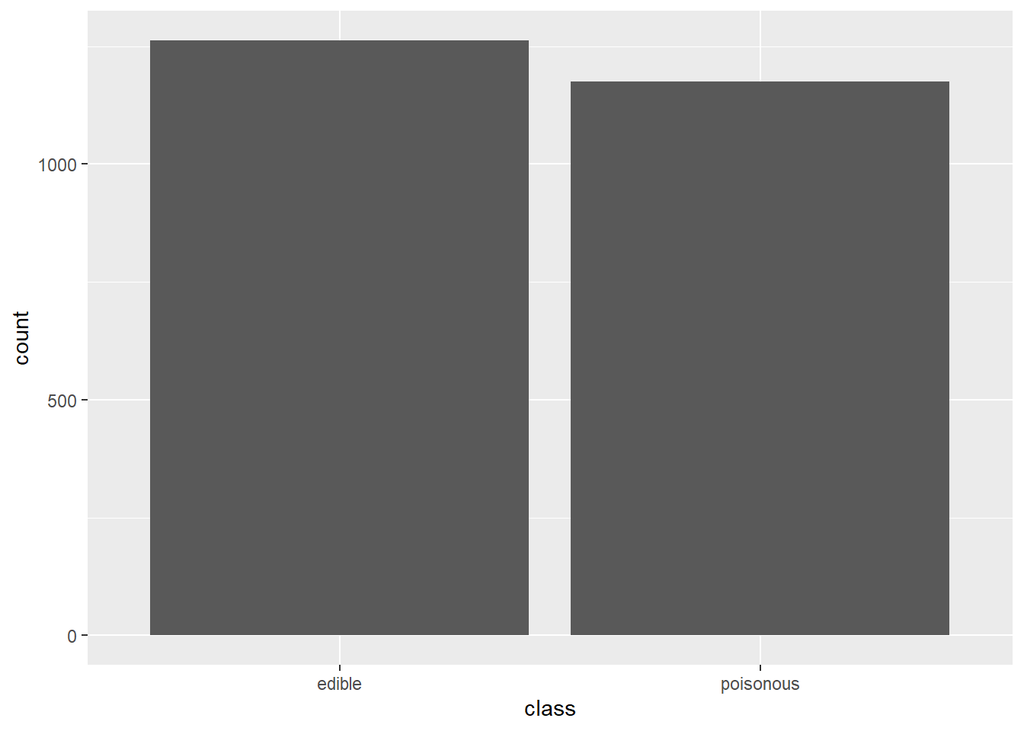

```r
bp_te1
```

4. Realice al menos 3 modelos vistos en clase

# Iniciando por el modelo de arbol de desiciones y se comprueba que el modelo es de clase rpart

```r
model_tree <- rpart(class ~ .,
                    data = agaricus_training,
                    method = "class" )
class(model_tree)
```

```
## [1] "rpart"
```

Evaluación del modelo

```r
predicted_model_tree <- predict(model_tree,
                                newdata = agaricus_test,
                                type = "class")
table(agaricus_test$class,
      predicted_model_tree)
```

```
##            predicted_model_tree
##             edible poisonous
##   edible      1262         0
##   poisonous     11      1164
```

# Para el modelo Random Forest

```r
model_rForest <- randomForest(class ~ ., data = agaricus_training)
```

A diferencia del modelo anterior, para este caso y probando varias semillas, random forest ha acertado todo el set de pruebas, sin fallar en ninguna prediccion (con los datos que se han probado hasta el).

```r
predicted_model_rForest <- predict(model_rForest,
                                   newdata = agaricus_test,
                                   type = "class")
table(agaricus_test$class,
      predicted_model_rForest)
```

```
##            predicted_model_rForest
##             edible poisonous
##   edible      1262         0
##   poisonous      0      1175
```

# Para el modelo de Regresion Logistica

Este modelo le es mas dificil trabajr con tantos parametros, por lo que hubo que escoger cuales podrian generar un mejor resultado

```r
model_rLogist <- glm(class ~ cap_shape +
                       cap_surface +
                       bruises +
                       odor +
                       gill_spacing +
                       gill_size  +
                       gill_color +
                       habitat,
                     data = agaricus_training,
                     family = binomial)
predicted_model_rLogist <- predict(model_rLogist,
                                   newdata = agaricus_test,
                                   type = "response")
table(agaricus_test$class,
      predicted_model_rLogist > 0.5)
```

```
##
##             FALSE TRUE
##   edible     1259    3
##   poisonous     0 1175
```

8. Desarolle al menos 3 conclusiones sobre las clasificaciones de los modelos

Para este ejemplo y con las semillas estudiadas, Random Forest tuvo siempre la mayor cantidad de aciertos.

Regresion Logistica tiene dificultades trabajando con muchas variables

Las predicciones de arboles de desicion son muy buenas, sin embargo tiene una ligera tendencia hacia los Falsos negativos (Predice No Venenosas cuando en pocos casos si lo eran)

# Realizando 100 pruebas

Si se realiza todo el procedimiento 100, se crean 100 sets de entrenamiento y se corre todo otra vez para cada uno de los modelos (con el mismo dataset en cada prueba), se tiene lo siguiente

```r
seed_vect = seq(1, 300, 3)
tamanho = length(seed_vect)
fn_t_results <- rep(0, tamanho)
fp_t_results <- rep(0, tamanho)
fn_rf_results <- rep(0, tamanho)
fp_rf_results <- rep(0, tamanho)
fn_rl_results <- rep(0, tamanho)
fp_rl_results <- rep(0, tamanho)

start_time <- Sys.time()

for (i in 1:tamanho){
  set.seed(seed_vect[i])
  split_var <- sample.split(agaricus$class,
                            SplitRatio = 0.7)
  agaricus_training <- agaricus[split_var,]
  agaricus_test <- agaricus[!split_var,]


# para regresion logistica

  model_tree <- rpart(class ~ .,
                    data = agaricus_training,
                    method = "class" )
  predicted_model_tree <- predict(model_tree,
                                  newdata = agaricus_test,
                                  type = "class")
  t_pred <- table(agaricus_test$class,
                  predicted_model_tree)
  fn_t_results[i] <- t_pred[2,1]
  fp_t_results[i] <- t_pred[1,2]


# para random Forest
  model_rForest <- randomForest(class ~ ., data = agaricus_training)
  predicted_model_rForest <- predict(model_rForest,
                                   newdata = agaricus_test,
                                   type = "class")
  rf_pred <- table(agaricus_test$class,
          predicted_model_rForest)

  fn_rf_results[i] <- rf_pred[2,1]
  fp_rf_results[i] <- rf_pred[1,2]

# para regresion logistica

  model_rLogist <- glm(class ~ cap_surface +
                       bruises +
                       odor +
                       gill_spacing +
                       gill_size  +
                       gill_color +
                       habitat,
                     data = agaricus_training,
                     family = binomial)

  predicted_model_rLogist <- predict(model_rLogist,
                                   newdata = agaricus_test,
                                   type = "response")
  rl_pred <- table(agaricus_test$class,
      predicted_model_rLogist > 0.5)

    fn_rl_results[i] <- rl_pred[2,1]
    fp_rl_results[i] <- rl_pred[1,2]

}
```

[output not shown]

[output cut: 144 more lines]

[output not shown]

```r
end_time <- Sys.time()
end_time - start_time
```

```
## Time difference of 1.602434 mins
```

El promedio de falsos negativos para los modelos “arbol de desicion”, “Random Forest” y “Regresion Logistica” son respectivamente de:

```r
  print(mean(fn_t_results))
```

```
## [1] 14.63
```

```r
  print(mean(fn_rf_results))
```

```
## [1] 0
```

```r
  print(mean(fn_rl_results))
```

```
## [1] 1.5
```

El maximo de falsos negativos para los modelos “arbol de desicion”, “Random Forest” y “Regresion Logistica” son respectivamente de:

```r
  print(max(fn_t_results))
```

```
## [1] 24
```

```r
  print(max(fn_rf_results))
```

```
## [1] 0
```

```r
  print(max(fn_rl_results))
```

```
## [1] 13
```

El minimo de falsos negativos para los modelos “arbol de desicion”, “Random Forest” y “Regresion Logistica” son respectivamente de:

```r
  print(min(fn_t_results))
```

```
## [1] 9
```

```r
  print(min(fn_rf_results))
```

```
## [1] 0
```

```r
  print(min(fn_rl_results))
```

```
## [1] 0
```

El promedio de falsos positivos para los modelos “arbol de desicion”, “Random Forest” y “Regresion Logistica” son respectivamente de:

```r
  print(mean(fp_t_results))
```

```
## [1] 0
```

```r
  print(mean(fp_rf_results))
```

```
## [1] 0
```

```r
  print(mean(fp_rl_results))
```

```
## [1] 3.42
```

El maximo de falsos positivos para los modelos “arbol de desicion”, “Random Forest” y “Regresion Logistica” son respectivamente de:

```r
  print(max(fp_t_results))
```

```
## [1] 0
```

```r
  print(max(fp_rf_results))
```

```
## [1] 0
```

```r
  print(max(fp_rl_results))
```

```
## [1] 7
```

El minimo de falsos positivos para los modelos “arbol de desicion”, “Random Forest” y “Regresion Logistica” son respectivamente de:

```r
  print(min(fp_t_results))
```

```
## [1] 0
```

```r
  print(min(fp_rf_results))
```

```
## [1] 0
```

```r
  print(min(fp_rl_results))
```

```
## [1] 0
```

# Lo cual lleva a la conclusion que para este set de datos el metodo que mejor predijo es “Random Forest” (pues no sequivoco en ninguna prediccion de las 100 veces que se corrio), lugo seguido de “regresion logistica” y por ultimo “arboles de decision”